# Week 4 - Linear Discriminant Analysis and K-Means

Kalle Kivinen

11/17/2020

## 2. The “Boston”-dataset

The dataset, “Boston,” used in this analysis can be dowloaded with the “MASS”-package. As such, it can be seen as a training dataset of sorts. It contains 14 variables with a (potential) connection to housing values in the suburbs of Boston. These variables are:

| Variable | Explanation |
| --- | --- |
| “crim” | per capita crime rate by town. |
| “zn” | proportion of residential land zoned for lots over 25,000 sq.ft. |
| “indus” | proportion of non-retail business acres per town. |
| “chas” | Charles River dummy variable (= 1 if tract bounds river; 0 otherwise). |
| “nox” | nitrogen oxides concentration (parts per 10 million). |
| “rm” | average number of rooms per dwelling. |
| “age” | proportion of owner-occupied units built prior to 1940. |
| “dis” | weighted mean of distances to five Boston employment centres. |
| “rad” | index of accessibility to radial highways. |
| “tax” | full-value property-tax rate per $10,000. |
| “ptratio” | pupil-teacher ratio by town. |
| “black” | 1000(Bk - 0.63)^2 where Bk is the proportion of blacks by town. |
| “lstat” | lower status of the population (percent). |
| “medv” | median value of owner-occupied homes in $1000s. |

```
## 'data.frame':    506 obs. of  14 variables:
##  $ crim   : num  0.00632 0.02731 0.02729 0.03237 0.06905 ...
##  $ zn     : num  18 0 0 0 0 0 12.5 12.5 12.5 12.5 ...
##  $ indus  : num  2.31 7.07 7.07 2.18 2.18 2.18 7.87 7.87 7.87 7.87 ...
##  $ chas   : int  0 0 0 0 0 0 0 0 0 0 ...
##  $ nox    : num  0.538 0.469 0.469 0.458 0.458 0.458 0.524 0.524 0.524 0.524 ...
##  $ rm     : num  6.58 6.42 7.18 7 7.15 ...
##  $ age    : num  65.2 78.9 61.1 45.8 54.2 58.7 66.6 96.1 100 85.9 ...
##  $ dis    : num  4.09 4.97 4.97 6.06 6.06 ...
##  $ rad    : int  1 2 2 3 3 3 5 5 5 5 ...
##  $ tax    : num  296 242 242 222 222 222 311 311 311 311 ...
##  $ ptratio: num  15.3 17.8 17.8 18.7 18.7 18.7 15.2 15.2 15.2 15.2 ...
##  $ black  : num  397 397 393 395 397 ...
##  $ lstat  : num  4.98 9.14 4.03 2.94 5.33 ...
##  $ medv   : num  24 21.6 34.7 33.4 36.2 28.7 22.9 27.1 16.5 18.9 ...
```

Each variable has 506 observations/points of data and the below computational analysis would seem to indicate that it contains no empty points of data and each of the 14x506=7084 observations is numeric/integer. Some observations are ratios, some percentages, and at least one (chas) is a dummy variable coded 0/1.

```r
Empty <- 0
for (x in row(Boston)){
  if (is.na(x) == TRUE){
    Empty <- Empty+1
  }
}

Numer <- 0
for (x in row(Boston)){
  if (is.numeric(x) == TRUE){
    Numer <- Numer+1
  }
}

Empty
```

```
## [1] 0
```

```r
Numer
```

```
## [1] 7084
```

## 3. The Graphical Overview of the Data.

Below, the reader can find the simple bar graphs of each variable, as well as a summary of each examined variable:

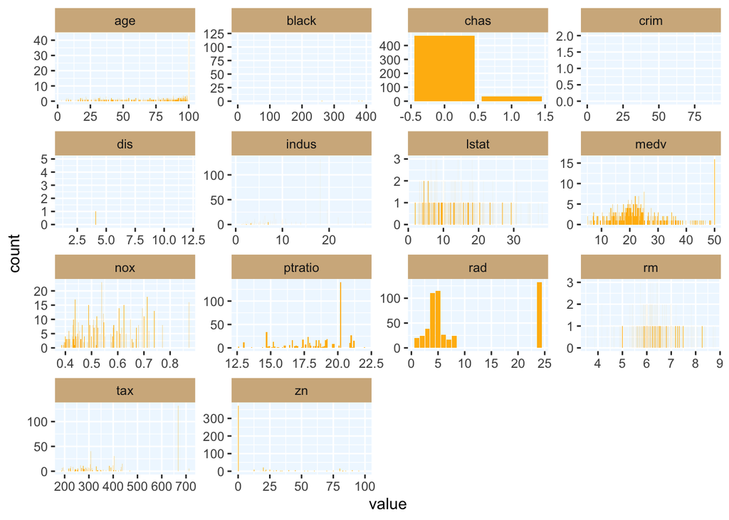

```
##       crim                zn             indus            chas
##  Min.   : 0.00632   Min.   :  0.00   Min.   : 0.46   Min.   :0.00000
##  1st Qu.: 0.08205   1st Qu.:  0.00   1st Qu.: 5.19   1st Qu.:0.00000
##  Median : 0.25651   Median :  0.00   Median : 9.69   Median :0.00000
##  Mean   : 3.61352   Mean   : 11.36   Mean   :11.14   Mean   :0.06917
##  3rd Qu.: 3.67708   3rd Qu.: 12.50   3rd Qu.:18.10   3rd Qu.:0.00000
##  Max.   :88.97620   Max.   :100.00   Max.   :27.74   Max.   :1.00000
##       nox               rm             age              dis
##  Min.   :0.3850   Min.   :3.561   Min.   :  2.90   Min.   : 1.130
##  1st Qu.:0.4490   1st Qu.:5.886   1st Qu.: 45.02   1st Qu.: 2.100
##  Median :0.5380   Median :6.208   Median : 77.50   Median : 3.207
##  Mean   :0.5547   Mean   :6.285   Mean   : 68.57   Mean   : 3.795
##  3rd Qu.:0.6240   3rd Qu.:6.623   3rd Qu.: 94.08   3rd Qu.: 5.188
##  Max.   :0.8710   Max.   :8.780   Max.   :100.00   Max.   :12.127
##       rad              tax           ptratio          black
##  Min.   : 1.000   Min.   :187.0   Min.   :12.60   Min.   :  0.32
##  1st Qu.: 4.000   1st Qu.:279.0   1st Qu.:17.40   1st Qu.:375.38
##  Median : 5.000   Median :330.0   Median :19.05   Median :391.44
##  Mean   : 9.549   Mean   :408.2   Mean   :18.46   Mean   :356.67
##  3rd Qu.:24.000   3rd Qu.:666.0   3rd Qu.:20.20   3rd Qu.:396.23
##  Max.   :24.000   Max.   :711.0   Max.   :22.00   Max.   :396.90
##      lstat            medv
##  Min.   : 1.73   Min.   : 5.00
##  1st Qu.: 6.95   1st Qu.:17.02
##  Median :11.36   Median :21.20
##  Mean   :12.65   Mean   :22.53
##  3rd Qu.:16.95   3rd Qu.:25.00
##  Max.   :37.97   Max.   :50.00
```

As the above general overview indicates, the data takes various values in various ranges - as one would expect from a dataset containing various different measures. Commenting on all the distributions seems pointless at first sight, but most of the graphs indicate some interesting things.

To begin with, we see the age-graph indicate an aging city. More importantly we see that its automatic scale seems off. Either there is a high amount of areas in the city where the proportion of buildings built before 1940 close to 100, or the dataset has a typo. Or, as a final thought that seems the most likely: many of properties surveyed for this dataset come from the same Boston town/area and hence share exactly the same variable observations for some area-specific variables.

We see the black-graph empty. Yet again, a closer examination (carried out below) shows that the data takes some interesting values. I do not have the knowledge to say what the measure “1000(Bk - 0.63)^2 where Bk is the proportion of blacks by town” should indicate, but a approx. 120 of the properties seem to get **a** value close to 397, while other values occur only once. In fact, the Summary statistic presented above shows that the value is probably 396,90 and that the variable is also curious since most of its observations are within the range of 370 and 400, but its smallest observation is 0.32. It might be that the small observation has not been multiplied by 1000 as per the formula, since the result would come close to the expected range. Yet again, this can be a sign of a typo, or something else going on. And as above, the repetition of one value might be explained by many of properties surveyed for this dataset coming from the same Boston town/area and hence sharing exactly the same variable observations for some area-specific variables.

The Crim-graph also looks empty, but again, the more detailed look below shows that most values range from 0 to 1, as one would expect from a per-capita rate. The fact that the general graph above has a range of 0 to 75 would indicate a typo or some placeholder value. Perhaps certain observations have been multiplied by hundred to give a percentage, or the person recording the obervation has forgotten a dot/comma. This would seem to be the case based on the summary statistic, since the max-values are high above the median and mean.

The dis-graph looks empty as well, but the below closer look shows the granular level of observations. With no aggregation, the single lines disappear from the graph when it is extended to contain all values. The summary statistic indicates nothing out of the ordinary.

The final empty-appearing graph, indus, seems to suffer from the same issue as the black-graph. As one can see below, most value-counts range between 0 and 10, but around the 17-mark there seems to be one value with a high count, approx 120, of observations. This same issue can also be observed in the tax-, rad-, and p-ratio- graphs, although **no** detailed look is carried out below. This is further evidence for the fact many of properties surveyed for this dataset might come from the same Boston town/area and hence share exactly the same variable observations for some area-specific variables.

Finally, the zn-graph looks odd as well, but I would argue that that is just the result of strict zoning-laws prohibiting the amount of large properties in most areas (observe the large count in value “0”)

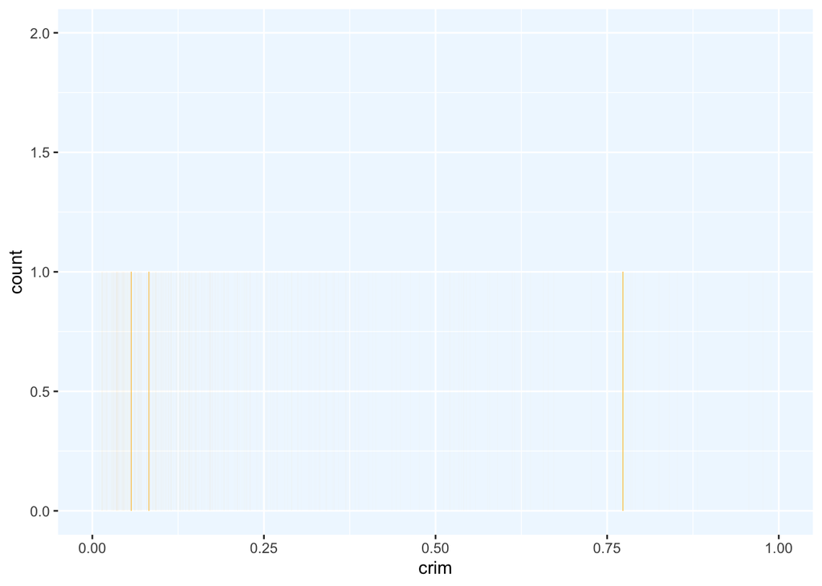

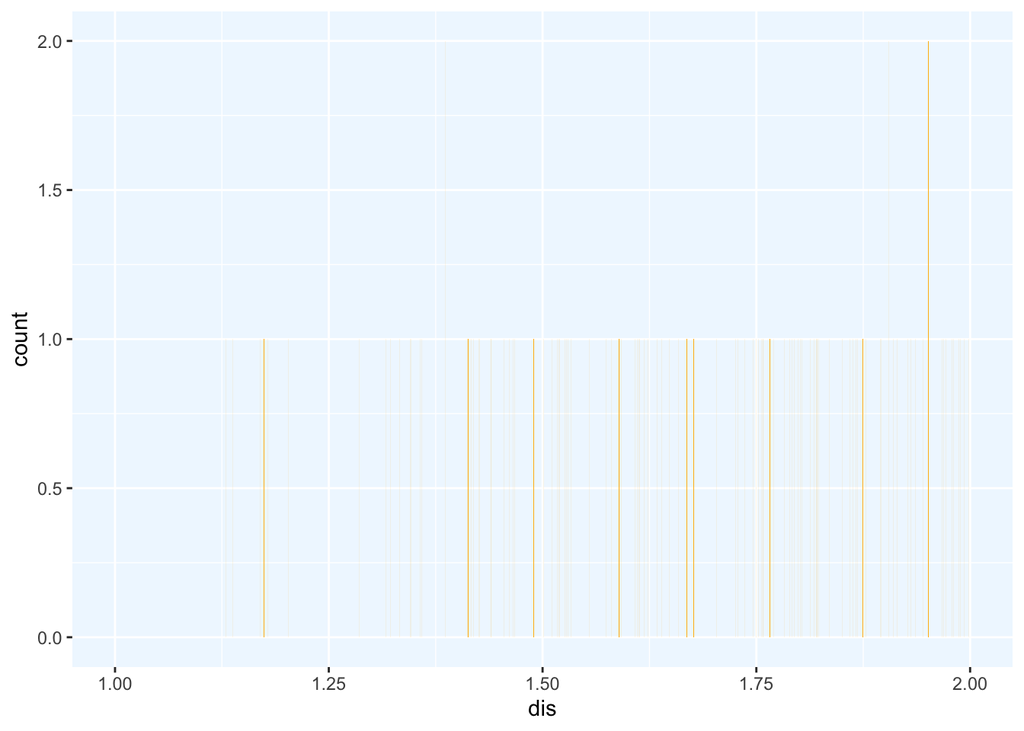

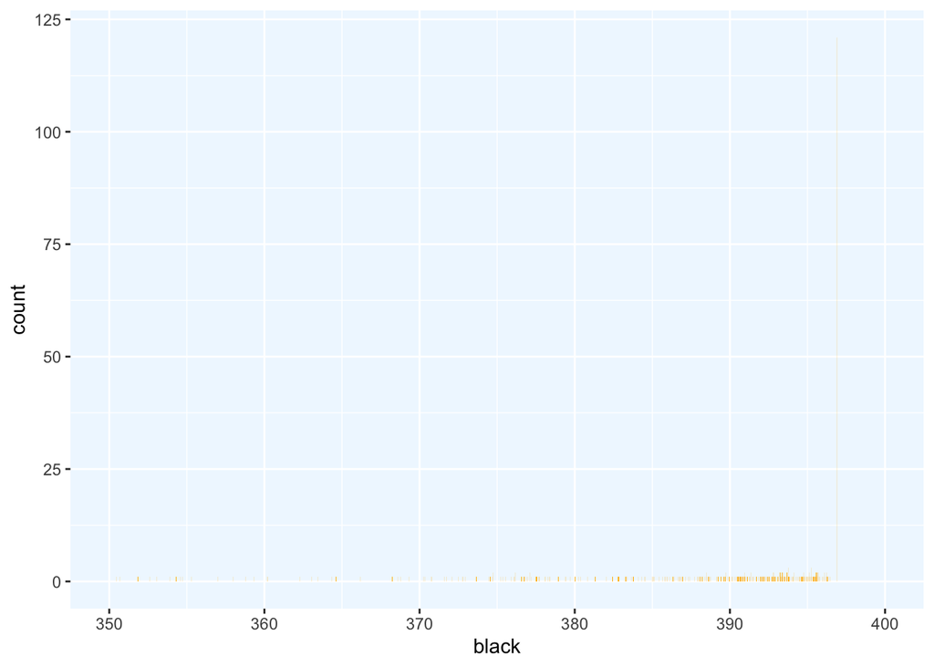

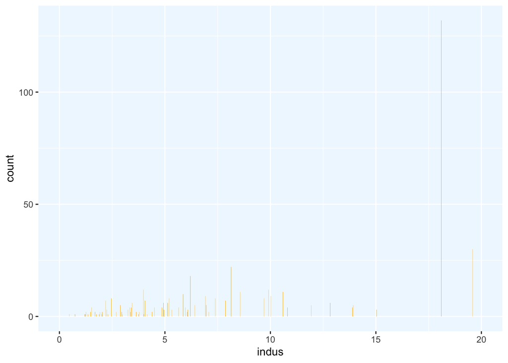

As for the relationships between the variables, the below matrix shows the correlations of each varibale paired with each of the ohters. Of note is the fact that the matrix seemingly indicates that each value has some statistically significant relationship with one each of the other variables. Of note is the only exception, the chas-variable, which is also the only dummy variable. An interesting question in this regard is why the chas variable is the only one that does not have statistically significant correlations with most other variables. The first answer is simple: because the fact that a tract bounds the river has no statistically significant impact on many of the other variables. The second option comes down to the inner workings of R - it might be that the cor.mtest-function used here to map p-values does not function well for dummy variables. No mention of this possibility is given by the ?cor.mtest-command.

On the other hand, it is perhaps not surprising that variables that are expected to be significant predictors of housing prices, also have statistically significant correlations which one-another. Out of these correlations a few should be highlighted in preparation for the coming faces. The variable “crim” (per-capita crime rate by town) seems to a a strong, statistically significant positive correlation with high property-tax properties, as well as properties with easier access to radial highways. Property-crime is a good explanatory factor for these correlations - high tax- and rad-variables indicate high-value targets(former) and/or easy get-away and access options(latter).

higher levels of industry (indus), house age (age), air pollution (nox), pupil-to-teacher ratio (ptratio), and population’s lower status all have a weaker positive correlation with crime rate. This perhaps indicates a second category of neighborhoods compared to the above: the older impoverished industry areas with less access to good education.

Both higher median value and longer distance from employment centers correlated weakly and negatively with a higher crime rate. I have a hard time explaining this. Perhaps it is due to the existence of middle-class suburbs, which are not attractive to property theft due to distance to a poor city center? This conclusion is perhaps supported by the strong negative correlation between the dis-variable on one hand and the indus-, nox-, and age-variables, which would seem to indicate that the (employment) centers of the city are older industry neighborhoods. All of this is of course anecdotal in the absence of clearer information.

Finally, the black-varibale seems to be negatively and weakly correlated with a higher crime rate, but as I do not understand the calculations behind the variable, it is rather hard to interpret the (potential) meaning of the correlation - as such I will drop it going forward.

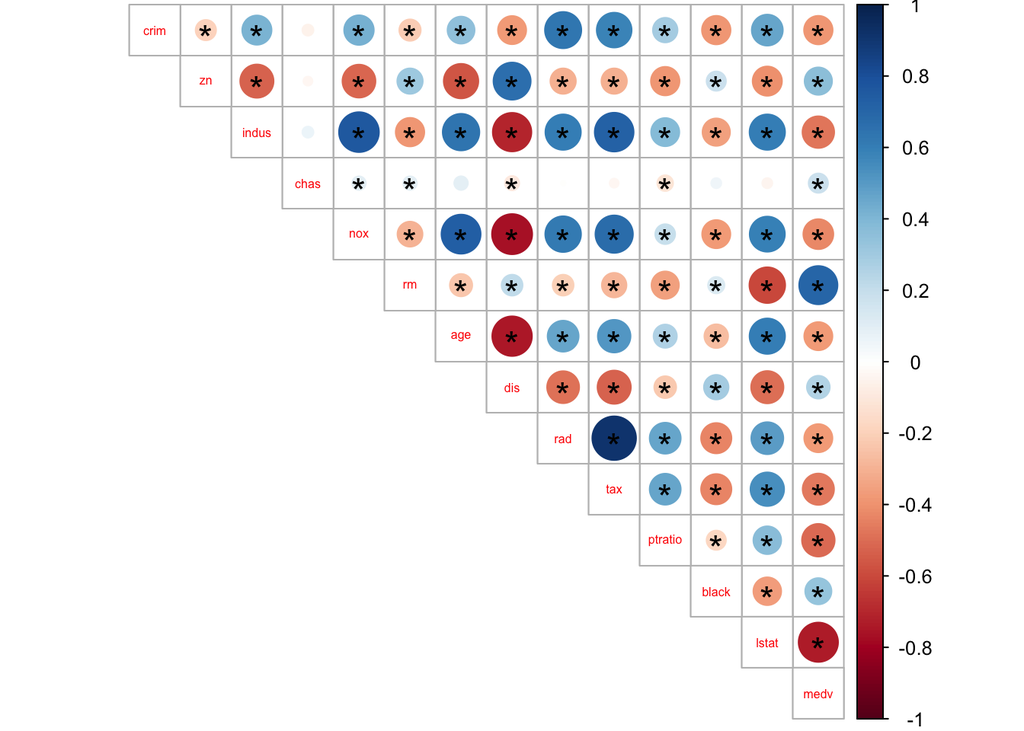

## 4. Standardization and Categorization

Below the reader can find a summary of the standardized Boston variables. All of them can be seen to share a mean of zero, which is of course by definition a feature of a standardized variable. They are also all on the same scale now, which means that they can be compared to one another easier - although that would not be immediately clear from the data, since the value-distributions still retain their curious aspects: for example with the variable “black,” the min is still far-far-far to the left from the rest of the data. Additionally, the standardized binomial variable “chas” has arguably become non-sensical. The old value of 0 has been replaced by -0.2723 and the old value for 1 has been replaced by 3.6648.

It should also be noted that none of the variables can be fully standardized into standard normal distributions, since they do not adhere to a normal distribution to begin with. This is, at least in, probably due to the (theorized) over representation of one neighborhood in the dataset.

```
##       crim                 zn               indus              chas
##  Min.   :-0.419367   Min.   :-0.48724   Min.   :-1.5563   Min.   :-0.2723
##  1st Qu.:-0.410563   1st Qu.:-0.48724   1st Qu.:-0.8668   1st Qu.:-0.2723
##  Median :-0.390280   Median :-0.48724   Median :-0.2109   Median :-0.2723
##  Mean   : 0.000000   Mean   : 0.00000   Mean   : 0.0000   Mean   : 0.0000
##  3rd Qu.: 0.007389   3rd Qu.: 0.04872   3rd Qu.: 1.0150   3rd Qu.:-0.2723
##  Max.   : 9.924110   Max.   : 3.80047   Max.   : 2.4202   Max.   : 3.6648
##       nox                rm               age               dis
##  Min.   :-1.4644   Min.   :-3.8764   Min.   :-2.3331   Min.   :-1.2658
##  1st Qu.:-0.9121   1st Qu.:-0.5681   1st Qu.:-0.8366   1st Qu.:-0.8049
##  Median :-0.1441   Median :-0.1084   Median : 0.3171   Median :-0.2790
##  Mean   : 0.0000   Mean   : 0.0000   Mean   : 0.0000   Mean   : 0.0000
##  3rd Qu.: 0.5981   3rd Qu.: 0.4823   3rd Qu.: 0.9059   3rd Qu.: 0.6617
##  Max.   : 2.7296   Max.   : 3.5515   Max.   : 1.1164   Max.   : 3.9566
##       rad               tax             ptratio            black
##  Min.   :-0.9819   Min.   :-1.3127   Min.   :-2.7047   Min.   :-3.9033
##  1st Qu.:-0.6373   1st Qu.:-0.7668   1st Qu.:-0.4876   1st Qu.: 0.2049
##  Median :-0.5225   Median :-0.4642   Median : 0.2746   Median : 0.3808
##  Mean   : 0.0000   Mean   : 0.0000   Mean   : 0.0000   Mean   : 0.0000
##  3rd Qu.: 1.6596   3rd Qu.: 1.5294   3rd Qu.: 0.8058   3rd Qu.: 0.4332
##  Max.   : 1.6596   Max.   : 1.7964   Max.   : 1.6372   Max.   : 0.4406
##      lstat              medv
##  Min.   :-1.5296   Min.   :-1.9063
##  1st Qu.:-0.7986   1st Qu.:-0.5989
##  Median :-0.1811   Median :-0.1449
##  Mean   : 0.0000   Mean   : 0.0000
##  3rd Qu.: 0.6024   3rd Qu.: 0.2683
##  Max.   : 3.5453   Max.   : 2.9865
```

The reader can also note that in this second set, the crim-varibale has been replaced by the Crime factor-variable, as per instructions, and the chas-variable has be returned to its original binomial state. Even further down, the reader can finally find the test set with the removed Crime variable, after the correct answers had been saved.

```
##           0%          25%          50%          75%         100%
## -0.419366929 -0.410563278 -0.390280295  0.007389247  9.924109610
```

```
##        zn               indus              nox                rm
##  Min.   :-0.48724   Min.   :-1.5563   Min.   :-1.4644   Min.   :-3.8764
##  1st Qu.:-0.48724   1st Qu.:-0.8668   1st Qu.:-0.9121   1st Qu.:-0.5681
##  Median :-0.48724   Median :-0.2109   Median :-0.1441   Median :-0.1084
##  Mean   : 0.00000   Mean   : 0.0000   Mean   : 0.0000   Mean   : 0.0000
##  3rd Qu.: 0.04872   3rd Qu.: 1.0150   3rd Qu.: 0.5981   3rd Qu.: 0.4823
##  Max.   : 3.80047   Max.   : 2.4202   Max.   : 2.7296   Max.   : 3.5515
##       age               dis               rad               tax
##  Min.   :-2.3331   Min.   :-1.2658   Min.   :-0.9819   Min.   :-1.3127
##  1st Qu.:-0.8366   1st Qu.:-0.8049   1st Qu.:-0.6373   1st Qu.:-0.7668
##  Median : 0.3171   Median :-0.2790   Median :-0.5225   Median :-0.4642
##  Mean   : 0.0000   Mean   : 0.0000   Mean   : 0.0000   Mean   : 0.0000
##  3rd Qu.: 0.9059   3rd Qu.: 0.6617   3rd Qu.: 1.6596   3rd Qu.: 1.5294
##  Max.   : 1.1164   Max.   : 3.9566   Max.   : 1.6596   Max.   : 1.7964
##     ptratio            black             lstat              medv
##  Min.   :-2.7047   Min.   :-3.9033   Min.   :-1.5296   Min.   :-1.9063
##  1st Qu.:-0.4876   1st Qu.: 0.2049   1st Qu.:-0.7986   1st Qu.:-0.5989
##  Median : 0.2746   Median : 0.3808   Median :-0.1811   Median :-0.1449
##  Mean   : 0.0000   Mean   : 0.0000   Mean   : 0.0000   Mean   : 0.0000
##  3rd Qu.: 0.8058   3rd Qu.: 0.4332   3rd Qu.: 0.6024   3rd Qu.: 0.2683
##  Max.   : 1.6372   Max.   : 0.4406   Max.   : 3.5453   Max.   : 2.9865
##      Crime      Boston.chas
##  Lowest :127   Min.   :0.00000
##  Lower  :126   1st Qu.:0.00000
##  Higher :126   Median :0.00000
##  Highest:127   Mean   :0.06917
##                3rd Qu.:0.00000
##                Max.   :1.00000
```

```
##        zn                indus               nox                 rm
##  Min.   :-0.487240   Min.   :-1.44698   Min.   :-1.46443   Min.   :-3.05520
##  1st Qu.:-0.487240   1st Qu.:-0.84242   1st Qu.:-0.73306   1st Qu.:-0.52395
##  Median :-0.487240   Median :-0.21089   Median :-0.14407   Median :-0.08843
##  Mean   : 0.008579   Mean   :-0.02197   Mean   : 0.01693   Mean   :-0.05395
##  3rd Qu.:-0.085267   3rd Qu.: 1.01499   3rd Qu.: 0.59809   3rd Qu.: 0.37163
##  Max.   : 3.800473   Max.   : 2.11552   Max.   : 2.72965   Max.   : 2.81002
##       age               dis                rad                 tax
##  Min.   :-2.1377   Min.   :-1.26230   Min.   :-0.981871   Min.   :-1.30676
##  1st Qu.:-0.6794   1st Qu.:-0.72229   1st Qu.:-0.637331   1st Qu.:-0.75050
##  Median : 0.4805   Median :-0.30999   Median :-0.522484   Median :-0.52355
##  Mean   : 0.1046   Mean   :-0.01178   Mean   :-0.004548   Mean   :-0.02665
##  3rd Qu.: 0.8668   3rd Qu.: 0.53822   3rd Qu.: 1.659603   3rd Qu.: 1.52941
##  Max.   : 1.1164   Max.   : 2.51419   Max.   : 1.659603   Max.   : 1.52941
##     ptratio            black              lstat               medv
##  Min.   :-2.7047   Min.   :-3.87836   Min.   :-1.32936   Min.   :-1.68888
##  1st Qu.:-0.3028   1st Qu.: 0.23943   1st Qu.:-0.66770   1st Qu.:-0.57440
##  Median : 0.3439   Median : 0.39587   Median :-0.09215   Median :-0.21559
##  Mean   : 0.1048   Mean   : 0.03159   Mean   :-0.01096   Mean   :-0.07755
##  3rd Qu.: 0.8058   3rd Qu.: 0.44062   3rd Qu.: 0.45399   3rd Qu.: 0.14865
##  Max.   : 1.2677   Max.   : 0.44062   Max.   : 3.54526   Max.   : 2.98650
##   Boston.chas
##  Min.   :0.00000
##  1st Qu.:0.00000
##  Median :0.00000
##  Mean   :0.04902
##  3rd Qu.:0.00000
##  Max.   :1.00000
```

## 5. Linear Discriminant Analysis (LDA)

```
## Call:
## lda(Crime ~ ., data = TrainSet)
##
## Prior probabilities of groups:
##    Lowest     Lower    Higher   Highest
## 0.2500000 0.2574257 0.2425743 0.2500000
##
## Group means:
##                  zn      indus        nox         rm        age        dis
## Lowest   0.91475727 -0.9272170 -0.8789912  0.4381487 -0.9062024  0.8770738
## Lower   -0.05599514 -0.2669954 -0.5964003 -0.1081667 -0.4166003  0.3919168
## Higher  -0.39011035  0.2135395  0.4402852  0.1416545  0.4210341 -0.4278647
## Highest -0.48724019  1.0171306  1.0488014 -0.4097280  0.8210011 -0.8535754
##                rad        tax    ptratio       black       lstat        medv
## Lowest  -0.6862262 -0.7399700 -0.4358781  0.38195384 -0.78226907  0.53652980
## Lower   -0.5478832 -0.4493226 -0.1011550  0.31610809 -0.12414468  0.01263791
## Higher  -0.3947467 -0.2931130 -0.3569977  0.06770335  0.02766381  0.23641534
## Highest  1.6379981  1.5139626  0.7806252 -0.80504861  0.89432666 -0.70062243
##         Boston.chas
## Lowest   0.03960396
## Lower    0.07692308
## Higher   0.12244898
## Highest  0.05940594
##
## Coefficients of linear discriminants:
##                       LD1         LD2         LD3
## zn           0.0770031374  0.57981191 -0.99648447
## indus        0.0215443139 -0.25771366  0.46734913
## nox          0.3829244187 -0.86330767 -1.24711553
## rm          -0.1306179333 -0.10668424 -0.07943848
## age          0.2204141135 -0.28839937 -0.16644673
## dis         -0.0752278914 -0.20317688  0.29609327
## rad          3.1954253192  0.84072211 -0.24826107
## tax         -0.0008648742  0.15005668  0.66404664
## ptratio      0.1024295682  0.02259716 -0.31869681
## black       -0.1280291867  0.03179795  0.14084301
## lstat        0.2210450433 -0.18483739  0.43792233
## medv         0.2204643388 -0.38989332 -0.14331373
## Boston.chas -0.3430456851 -0.10097436  0.49060792
##
## Proportion of trace:
##    LD1    LD2    LD3
## 0.9473 0.0384 0.0143
```

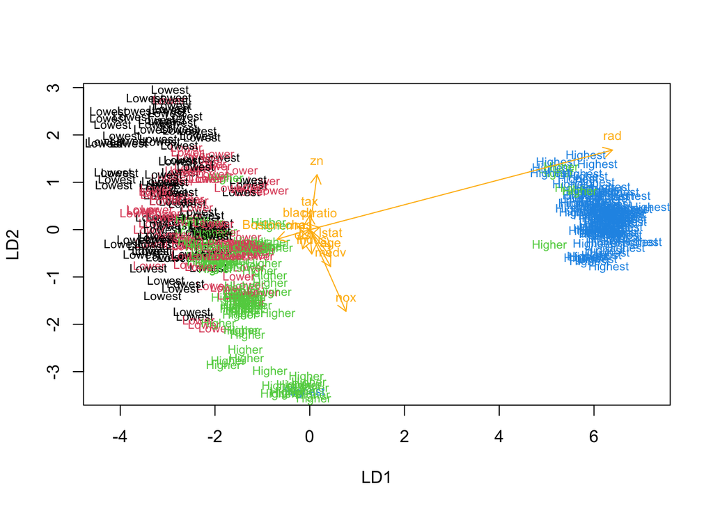

## 6. LDA for Prediction

```
##          predicted
## correct   Lowest Lower Higher Highest
##   Lowest      19     6      1       0
##   Lower        2    16      4       0
##   Higher       1    11     15       1
##   Highest      0     0      0      26
```

## 7. K-Means Analysis

The below two graphs showcase the results of the final K-Means analysis. The first graph details the change the total within cluster sum of squares as we increase the amount of clusters from 1 to 14. The aim is to use the graph to find the optimal amount of clusters. As it is clear that a more granular level will lead to smaller within cluster sum of squares (WCSS) without necessarily being a better grouping devise (Consider for example that the smallest within cluster sum of squares comes from having only one observation in each “cluster”, meaning that no clustering has been done), we need to find a point where the WCSS drops drastically, indicating an amount of clusters that is significantly more precise than a smaller amount, but not significantly less precise than a larger amount. The first graph indicates that that point is two (2) clusters.

```
##    Min. 1st Qu.  Median    Mean 3rd Qu.    Max.
##  0.1343  3.2663  4.6116  4.7275  5.9572 13.8843
```

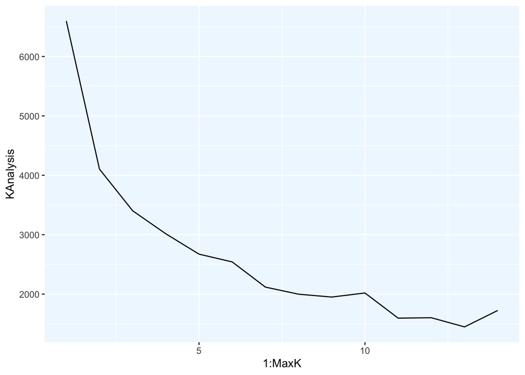

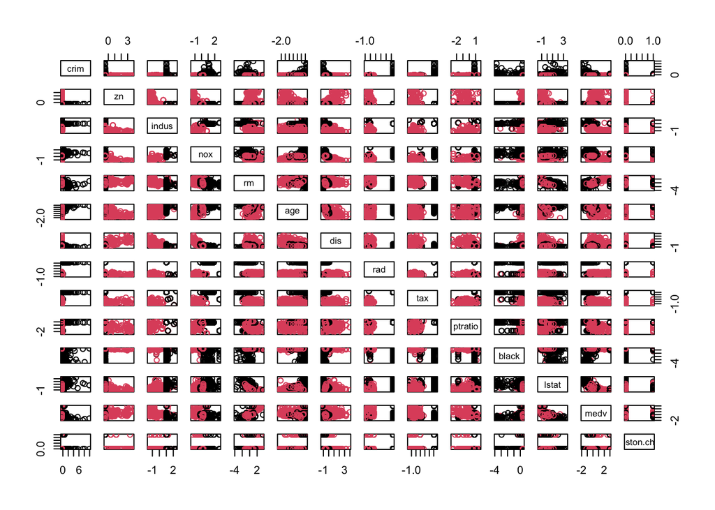